# Lecturer Questions: Question chains

George Kinnear

2024-04-04

```r
library(tidyverse)
library(janitor)

# Tables
library(knitr)
library(kableExtra)
basic_kable = function(df, ...) {
  df %>%
    kable(...) %>%
    kable_styling(bootstrap_options = "striped", full_width = F)
}

# Plot styling
theme_set(theme_minimal())
```

```r
all_qs_all_lecs <- read_csv("data/ANON_LQ_Maths_All.csv")
anon_courses <- read_csv("data/ANON_courses.csv")

codes <- c("A", "C", "E", "F", "N", "O", "P", "U", "W", "X")
# Collapsing C, P, X, O into Other
collapsed_codes <- c("A", "O", "E", "F", "N", "O", "O", "U", "W", "O")

code_names <- c("Admin", "Convention", "Evaluation", "Fact", "Next step", "Other",
                "Proof framework", "Understanding check", "Warrant", "Example generation")

code_details <- tibble(code = codes, code_name = code_names) %>%
  mutate(
    collapsed_code = case_when(
      code %in% c("C", "P", "X", "O") ~ "Other",
      TRUE ~ code_name
    )
  ) %>%
  add_row(
    code = "Total",
    code_name = "Total",
    collapsed_code = "Total"
  )

# Making list of all lectures and category code combos
lec_cat <- expand_grid(
  all_qs_all_lecs %>% select(course, session) %>% distinct(),
  category = codes
)
```

Just as a check, here is the total number of questions in the data we have loaded:

```r
all_qs <- all_qs_all_lecs %>%
  filter(!is.na(code_name))

all_qs %>%
  tally(name = "num_qs") %>%
  basic_kable()
```

| num_qs |
| --- |
| 2460 |

# Question chains

## Prevalence

A majority of questions are part of a chain:

```r
all_qs %>%
  mutate(part_of_chain = str_detect(cluster_q, "Y")) %>%
  tabyl(part_of_chain) %>%
  adorn_pct_formatting() %>%
  basic_kable(booktabs = T)
```

| part_of_chain | n | percent |
| --- | --- | --- |
| FALSE | 1094 | 44.5% |
| TRUE | 1366 | 55.5% |

## Untangling U and A

```r
numbered_chains <- all_qs %>%
  #filter(!category %in% c("A", "U")) %>%
  filter(str_detect(cluster_q, "Y")) %>%
  group_by(course, session, cluster_q) %>%
  mutate(
    chain_id = cur_group_id(),
    num_in_chain = n(),
    pos_within_chain = row_number(),
    excluded_qs = sum(category=="A") + sum(category=="U")
  ) %>%
  bind_rows(
    all_qs %>%
      filter(cluster_q == "N") %>%
      mutate(num_in_chain = 1, pos_within_chain = 1, excluded_qs = 1)
  ) %>%
  mutate(num_in_chain = as.numeric(num_in_chain))

chains_excluding_AU_pivot <- numbered_chains %>%
  ungroup() %>%
  # add a chain ID for each single question
  mutate(
    chain_id = ifelse(is.na(chain_id), 5000+row_number(), chain_id),
  ) %>%
  select(chain_id, num_in_chain, excluded_qs) %>%
  distinct() %>%
  tabyl(num_in_chain, excluded_qs)

chains_excluding_AU_pivot %>%
  basic_kable(booktabs = T) %>%
  add_header_above(c(" " = 1, "Number of A/U questions excluded" = 5))
```

| num_in_chain | Number of A/U questions excluded 0 | Number of A/U questions excluded 1 | Number of A/U questions excluded 2 | Number of A/U questions excluded 3 | Number of A/U questions excluded 4 |
| --- | --- | --- | --- | --- | --- |
| 1 | 0 | 1094 | 0 | 0 | 0 |
| 2 | 256 | 5 | 103 | 0 | 0 |
| 3 | 88 | 2 | 0 | 27 | 0 |
| 4 | 35 | 1 | 1 | 0 | 6 |
| 5 | 14 | 0 | 0 | 0 | 0 |
| 6 | 5 | 0 | 0 | 0 | 0 |
| 7 | 1 | 0 | 0 | 0 | 0 |
| 8 | 1 | 0 | 0 | 0 | 0 |

This shows that in almost all cases, the number of excluded questions matches the size of the chain – so chains tend to be either all A/U or all non-A/U.

Investigating this further – here we pick out all the cases where a chain is partly made up of A/U:

```r
numbered_chains %>%
  ungroup() %>%
  filter(excluded_qs > 0, excluded_qs < num_in_chain) %>%
  select(course, session, chain_id, cluster_q, category, question) %>%
  basic_kable(booktabs = T,
        caption = "Chains where one of the questions is A/U") %>%
  collapse_rows(columns = 1:4, valign = "top")
```

Chains where one of the questions is A/U

| course | session | chain_id | cluster_q | category | question |
| --- | --- | --- | --- | --- | --- |
| 2A_L22 | S2 | 452 | Y5 | A | oh you want to say 1/6? |
|  |  |  |  | W | Because theres kind of 1/6 chance each time? |
| 1C_L15 | S1 | 44 | Y2 | U | So did that kind of answer your question about what’s the difference between the magnitude and the double bars? |
|  |  |  |  | C | Anyone want to respond to that? |
|  |  |  |  | C | What’s the difference here? |
|  |  |  |  | C | Single bar and double bar? |
|  |  | 46 | Y4 | F | What does the shadow of the vector look like projecting down onto the vector? |
|  |  |  |  | U | If you’re already on the vector, the shadow is itself - right? |
| 3C_L13 | S4 | 524 | Y2 | F | For which matrices does this happen? |
|  |  |  |  | F | Which class of matrices? |
|  |  |  |  | U | So that rings a bell or not? |
| 1D_L21 | S1 | 345 | Y3 | F | Now how about this step? |
|  |  |  |  | F | How far can a0 point a1a2 be away from x? |
|  |  |  |  | A | I’m sorry? |
| 2C_L23 | S3 | 501 | Y2 | U | is everyone clear where this sin(t) and this sin(t) come from? |
|  |  |  |  | F | where did we get the y and the z? |
| 1C_L17 | S6 | 314 | Y4 | E | is anyone not convinced by this [proof]? |
|  |  |  |  | U | would anyone like more detail [about why the proof is true]? |
|  | S8 | 317 | Y1 | U | right? |
|  |  |  |  | N | and now what? |
| 1C_L16 | S3 | 180 | Y18 | W | Can anyone give an argument for it? |
|  |  |  |  | W | Or a proof, better. |
|  |  |  |  | A | Was that a someone up the back? |
|  |  |  |  | A | No, you just stretching? |

These are really quite rare:

```r
affected_chains <- numbered_chains %>%
  ungroup() %>%
  mutate(affected = excluded_qs > 0 & excluded_qs < num_in_chain) %>%
  select(chain_id, affected) %>%
  distinct() %>%
  tabyl(affected)

affected_chains %>%
  basic_kable(booktabs = T)
```

| affected | n | percent |
| --- | --- | --- |
| FALSE | 537 | 0.9835165 |
| TRUE | 9 | 0.0164835 |

Thus, in the following analyses, we first **omit all A/U questions**.

# Question chain frequencies

After discarding all A/U questions, chains are even more frequent:

```r
all_qs %>%
  filter(!category %in% c("A", "U")) %>%
  mutate(part_of_chain = str_detect(cluster_q, "Y")) %>%
  tabyl(part_of_chain) %>%
  adorn_pct_formatting() %>%
  basic_kable(booktabs = T)
```

| part_of_chain | n | percent |
| --- | --- | --- |
| FALSE | 575 | 35.5% |
| TRUE | 1045 | 64.5% |

How frequent are chains of different lengths?

```r
numbered_chains <- all_qs %>%
  filter(!category %in% c("A", "U")) %>%
  filter(str_detect(cluster_q, "Y")) %>%
  group_by(course, session, cluster_q) %>%
  mutate(
    chain_id = cur_group_id(),
    num_in_chain = n(),
    pos_within_chain = row_number()
  ) %>%
  bind_rows(
    all_qs %>%
      filter(!category %in% c("A", "U")) %>%
      filter(cluster_q == "N") %>%
      mutate(num_in_chain = 1, pos_within_chain = 1)
  ) %>%
  mutate(num_in_chain = as.numeric(num_in_chain)) %>%
  # remove the very small number of chains (5) which now only have 1 questions after A/U were removed
  mutate(chain_id = ifelse(num_in_chain==1, NA, chain_id)) %>%
  ungroup()

numbered_chains %>%
  filter(!is.na(chain_id)) %>%
  # make sure all lectures appear, including those with counts of 0
  right_join(
    lec_cat %>% select(course, session),
    by = c("course", "session")
  ) %>%
  replace_na(list(num_in_chain = 0)) %>%
  group_by(course, session) %>%
  summarise(
    num_chains = n_distinct(chain_id, na.rm = TRUE),
    chain_size_mean = mean(num_in_chain, na.rm = TRUE),
    chain_size_max = max(num_in_chain, na.rm = TRUE),
    .groups = "drop"
  ) %>%
  head() %>%
  basic_kable(booktabs = T,
              caption = "Excerpt of table showing number of chains and the mean/max chain size in each session")
```

Excerpt of table showing number of chains and the mean/max chain size in each session

| course | session | num_chains | chain_size_mean | chain_size_max |
| --- | --- | --- | --- | --- |
| 1A_L1 | S1 | 1 | 5.000000 | 5 |
| 1A_L1 | S2 | 0 | 0.000000 | 0 |
| 1A_L1 | S3 | 3 | 2.750000 | 3 |
| 1A_L1 | S4 | 6 | 2.733333 | 4 |
| 1A_L2 | S1 | 2 | 4.000000 | 4 |
| 1A_L2 | S2 | 2 | 2.000000 | 2 |

Looking at the chains, they tend to be quite small but there are a few larger ones:

```r
numbered_chains %>%
  #filter(!is.na(chain_id)) %>%
  #ungroup() %>%
  filter(num_in_chain > 1) %>%
  select(chain_id, num_in_chain) %>%
  distinct() %>%
  summarise(
    num_chains = n_distinct(chain_id),
    chain_size_mean = mean(num_in_chain),
    chain_size_median = median(num_in_chain),
    chain_size_sd = sd(num_in_chain),
    chain_size_max = max(num_in_chain)
  ) %>%
  basic_kable()
```

| num_chains | chain_size_mean | chain_size_median | chain_size_sd | chain_size_max |
| --- | --- | --- | --- | --- |
| 404 | 2.574257 | 2 | 0.9487778 | 8 |

```r
numbered_chains %>%
  filter(!is.na(chain_id)) %>%
  select(num_in_chain, chain_id) %>%
  distinct() %>%
  tabyl(num_in_chain) %>%
  adorn_pct_formatting() %>%
  basic_kable()
```

| num_in_chain | n | percent |
| --- | --- | --- |
| 2 | 259 | 64.1% |
| 3 | 89 | 22.0% |
| 4 | 35 | 8.7% |
| 5 | 14 | 3.5% |
| 6 | 5 | 1.2% |
| 7 | 1 | 0.2% |
| 8 | 1 | 0.2% |

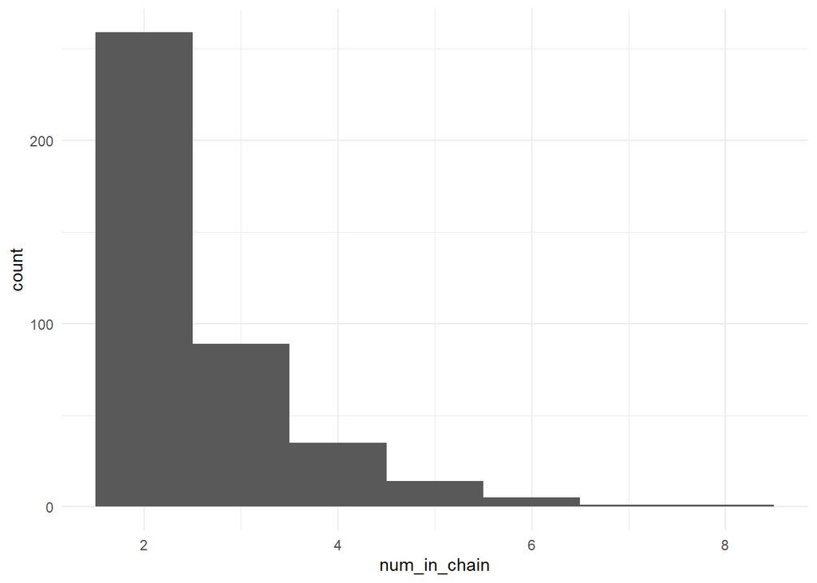

```r
numbered_chains %>%
  filter(!is.na(chain_id)) %>%
  select(num_in_chain, chain_id) %>%
  distinct() %>%
  ggplot(aes(x = num_in_chain)) +
    geom_histogram(binwidth = 1)
```

## Chains and responses

```r
chain_response_rates <- numbered_chains %>%
  filter(!category %in% c("A", "U")) %>%
  ungroup() %>%
  #filter(!is.na(chain_id)) %>%
  mutate(
    chain_id = ifelse(is.na(chain_id), 5000+row_number(), chain_id)
  ) %>%
  group_by(num_in_chain, chain_id) %>%
  summarise(got_a_response = last(student_response), .groups = "drop") %>%
  tabyl(num_in_chain, got_a_response) %>%
  adorn_percentages("row") %>%
  adorn_pct_formatting(digits = 0) %>%
  adorn_ns()
```

```r
chain_responses_table <- numbered_chains %>%
  #filter(!is.na(chain_id)) %>%
  mutate(
    chain_id = ifelse(is.na(chain_id), 5000+row_number(), chain_id),
    num_in_chain = ifelse(num_in_chain==1, "Single question", "Question chain")
  ) %>%
  group_by(num_in_chain, chain_id) %>%
  summarise(got_a_response = last(student_response), .groups = "drop") %>%
  tabyl(num_in_chain, got_a_response) %>%
  adorn_percentages("row") %>%
  adorn_pct_formatting(digits = 0) %>%
  adorn_ns() %>%
  arrange(desc(num_in_chain)) %>%
  # add rows showing the detail on genuine chains
  bind_rows(
    chain_response_rates %>%
      filter(num_in_chain > 1) %>%
      #mutate(num_in_chain = as.character(num_in_chain))
      mutate(num_in_chain = paste(num_in_chain, "questions"))
  )

chain_responses_table %>%
  kable(booktabs = T,
         col.names = c("", "No", "Yes")) %>%
    kable_styling(full_width = F) %>%
    #pack_rows("Question chain size", 3, 9) %>%
    add_indent(c(3:9)) %>%
    add_header_above(c(" " = 1, "Student response" = 2))
```

|  | Student response No | Student response Yes |
| --- | --- | --- |
| Single question | 14% (81) | 86% (499) |
| Question chain | 16% (63) | 84% (341) |
| 2 questions | 17% (44) | 83% (215) |
| 3 questions | 15% (13) | 85% (76) |
| 4 questions | 9% (3) | 91% (32) |
| 5 questions | 14% (2) | 86% (12) |
| 6 questions | 20% (1) | 80% (4) |
| 7 questions | 0% (0) | 100% (1) |
| 8 questions | 0% (0) | 100% (1) |

**LaTeX table**

```r
chain_responses_table %>%
  kable(booktabs = T,
        format = "latex",
         col.names = c("", "No", "Yes")) %>%
    kable_styling(full_width = F) %>%
    #pack_rows("Question chain size", 3, 9) %>%
    add_indent(c(3:9)) %>%
    add_header_above(c(" " = 1, "Student response" = 2)) %>%
  cat()
```

```
## \begin{table}
## \centering
## \begin{tabular}{lll}
## \toprule
## \multicolumn{1}{c}{ } & \multicolumn{2}{c}{Student response} \\
## \cmidrule(l{3pt}r{3pt}){2-3}
##  & No & Yes\\
## \midrule
## Single question & 14\% (81) & 86\% (499)\\
## Question chain & 16\% (63) & 84\% (341)\\
## \hspace{1em}2 questions & 17\% (44) & 83\% (215)\\
## \hspace{1em}3 questions & 15\% (13) & 85\%  (76)\\
## \hspace{1em}4 questions & 9\%  (3) & 91\%  (32)\\
## \addlinespace
## \hspace{1em}5 questions & 14\%  (2) & 86\%  (12)\\
## \hspace{1em}6 questions & 20\%  (1) & 80\%   (4)\\
## \hspace{1em}7 questions & 0\%  (0) & 100\%   (1)\\
## \hspace{1em}8 questions & 0\%  (0) & 100\%   (1)\\
## \bottomrule
## \end{tabular}
## \end{table}
```

# Analysis of the chains

```r
chain_summaries <- numbered_chains %>%
  filter(!category %in% c("A", "U")) %>%
  ungroup() %>%
  mutate(
    chain_id = ifelse(is.na(chain_id), 5000+row_number(), chain_id)
  ) %>%
  group_by(chain_id) %>%
  summarise(
    category_chain = paste0(category, collapse = ''),
    chain_len = n(),
    codes_used = n_distinct(category)
  ) %>%
  arrange(-chain_len)
```

Most chains consist of questions of a single type:

```r
options(knitr.kable.NA = '')

chain_summaries_nums <-
chain_summaries %>%
  group_by(chain_len, codes_used) %>%
  tally() %>%
  pivot_wider(
    names_from = codes_used,
    values_from = n
  )

chain_summaries_nums %>%
  filter(chain_len > 1) %>%
  # make the chain_len a string so it's not added to the totals!
  mutate(chain_len = paste("", chain_len)) %>%
  adorn_totals() %>%
  basic_kable() %>%
  add_header_above(c(" " = 1, "Number of codes used" = 3))
```

| chain_len | Number of codes used 1 | Number of codes used 2 | Number of codes used 3 |
| --- | --- | --- | --- |
| 2 | 236 | 23 |  |
| 3 | 72 | 16 | 1 |
| 4 | 28 | 6 | 1 |
| 5 | 9 | 4 | 1 |
| 6 | 3 | 2 |  |
| 7 | 1 |  |  |
| 8 |  | 1 |  |
| Total | 349 | 52 | 3 |

Look at the more diverse chains:

```r
diverse_chains <-
chain_summaries %>%
  filter(codes_used > 1) %>%
  filter(codes_used > 2 | chain_len+codes_used > 5) %>%
  arrange(-codes_used, chain_len)

numbered_chains %>%
  ungroup() %>%
  right_join(diverse_chains, by = "chain_id") %>%
  select(category_chain, course, session, category, question)
```

| category_chain | course | session | category | question |
| --- | --- | --- | --- | --- |
| OOXXX | 3A_L11 | S1 | O | do you remember what the most important basic theorem that you learned was [in FPM]? |
| OOXXX | 3A_L11 | S1 | O | don't be scared, I'll be interested to see what you think |
| OOXXX | 3A_L11 | S1 | X | I need you to choose 6 numbers for me though? |
| OOXXX | 3A_L11 | S1 | X | I need you to choose them? |
| OOXXX | 3A_L11 | S1 | X | 6 numbers? |
| NEEW | 1A_L1 | S4 | N | The logarithm of x^2+3 - what can we say about that? |
| NEEW | 1A_L1 | S4 | E | Will that guy ever be zero? |
| NEEW | 1A_L1 | S4 | E | Yes or no? |
| NEEW | 1A_L1 | S4 | W | Why will it never be zero? |
| NFNN | 3C_L13 | S4 | N | Using our implicit boundary condition of boundedness, what can we say? |

[output cut: 66 more lines]

These are all the chains of size 2 where both questions are of the same type:

```r
numbered_chains %>%
  ungroup() %>%
  right_join(
    chain_summaries %>%
      filter(codes_used == 1, chain_len == 2),
    by = "chain_id"
  ) %>%
  select(chain_id, category_chain, course, session, category, question)
```

| chain_id | category_chain | course | session | category | question |
| --- | --- | --- | --- | --- | --- |
| 371 | NN | 2B_L8 | S1 | N | Let x_n be an unbounded increasing sequence, then what's my conclusion? |
| 371 | NN | 2B_L8 | S1 | N | What happens? |
| 373 | XX | 2B_L8 | S2 | X | somebody give me a value of epsilon? |
| 373 | XX | 2B_L8 | S2 | X | think of a positive real number someone |
| 378 | WW | 3A_L11 | S1 | W | who would like to have a guess about why that map is injective? |
| 378 | WW | 3A_L11 | S1 | W | could it be anything to do with linear independence? |
| 381 | FF | 3A_L11 | S2 | F | what are the units in Z? |
| 381 | FF | 3A_L11 | S2 | F | suggestions? |
| 339 | FF | 2A_L22 | S2 | F | what do we expect the answer to be? [referring to the expected value of a binomial random variable] |
| 339 | FF | 2A_L22 | S2 | F | [breaks down the question as a statement] what do you think the expected number of successes in total is? |

[output cut: 462 more lines]

This shows the number of chains of each type signature:

```r
chain_summaries %>%
  filter(chain_len > 1) %>%
  group_by(category_chain) %>%
  tally() %>%
  arrange(-n) %>%
  basic_kable()
```

| category_chain | n |
| --- | --- |
| NN | 77 |
| FF | 71 |
| WW | 53 |
| NNN | 25 |
| EE | 21 |
| FFF | 20 |
| WWW | 16 |
| FFFF | 10 |
| NNNN | 10 |
| XX | 8 |
| EEE | 7 |
| OO | 6 |
| FE | 5 |
| NE | 5 |
| NF | 5 |
| NNNNN | 5 |
| WWWW | 5 |
| FFFFF | 4 |
| EEEE | 3 |
| NFF | 3 |
| XXX | 3 |
| EX | 2 |
| FFFFFF | 2 |
| NNE | 2 |
| WE | 2 |
| WEE | 2 |
| CCC | 1 |
| EEEEW | 1 |
| EF | 1 |
| EFF | 1 |
| EN | 1 |
| EW | 1 |
| FFE | 1 |
| FFFE | 1 |
| FFFEE | 1 |
| FFFEFE | 1 |
| FFFFFFF | 1 |
| FWW | 1 |
| NEEE | 1 |
| NEEW | 1 |
| NFE | 1 |
| NFNN | 1 |
| NNEFF | 1 |
| NNF | 1 |
| NNNF | 1 |
| NNNFN | 1 |
| NNNNNN | 1 |
| NNW | 1 |
| NOOOOO | 1 |
| OOOOOEEE | 1 |
| OOXXX | 1 |
| PNN | 1 |
| WN | 1 |
| WNN | 1 |
| WWF | 1 |
| WWFF | 1 |
| WWFW | 1 |
| WXX | 1 |

## Categories

### Means per lecture

```r
numbered_chains %>%
  filter(!code_name %in% c("Total", "Admin", "Understanding check")) %>%
  group_by(course, session, code_name) %>%
  summarise(
    num_qs = n(),
    num_single_qs = sum(is.na(chain_id)),
    num_chain_qs = sum(!is.na(chain_id))
  ) %>%
  ungroup() %>%
    group_by(code_name) %>%
    summarise(across(contains("num_"), list(mean = mean)), .groups = "drop_last")
```

| code_name | num_qs_mean | num_single_qs_mean | num_chain_qs_mean |
| --- | --- | --- | --- |
| Convention | 2.000000 | 0.500000 | 1.500000 |
| Evaluation | 3.818182 | 1.654545 | 2.163636 |
| Example generation | 3.312500 | 1.312500 | 2.000000 |
| Fact | 6.216867 | 2.313253 | 3.903614 |
| Next step | 7.609375 | 2.250000 | 5.359375 |
| Other | 2.375000 | 0.875000 | 1.500000 |
| Proof framework | 1.600000 | 1.400000 | 0.200000 |
| Warrant | 4.606061 | 1.666667 | 2.939394 |

```
## `mutate_all()` ignored the following grouping variables:
```

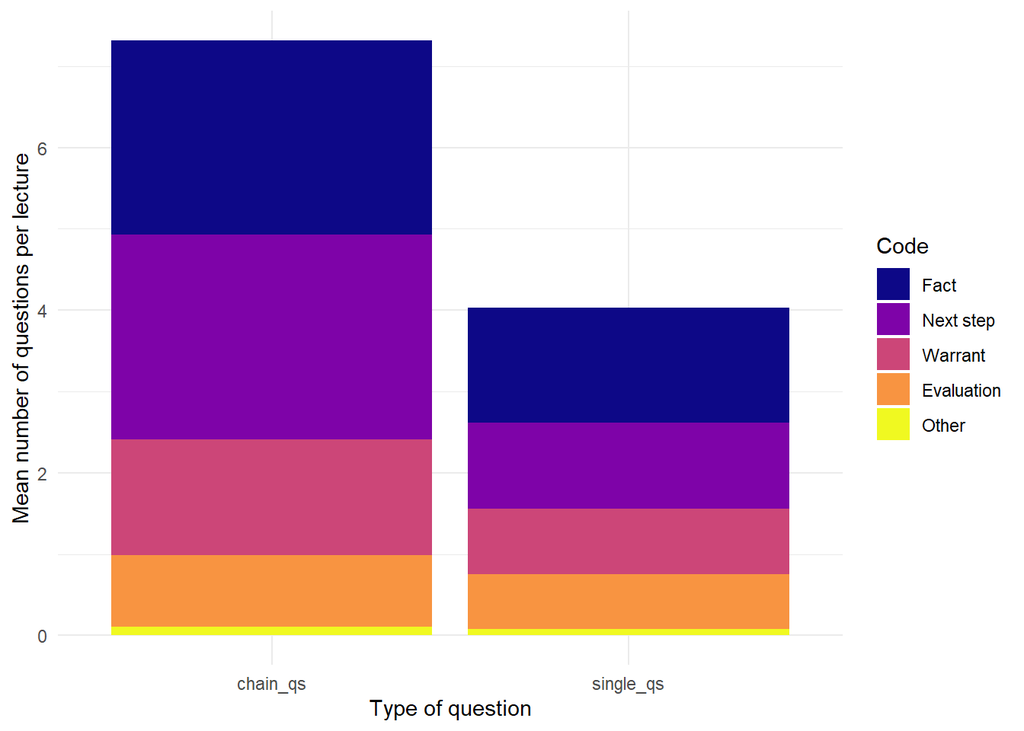

```r
numbered_chains %>%
  #filter(!code_name %in% c("Total", "Admin", "Understanding check")) %>%
  # focus on single questions
  #filter(is.na(chain_id)) %>%
  group_by(course, session, category, code_name) %>%
  summarise(
    num_qs = n(),
    num_single_qs = sum(is.na(chain_id)),
    num_chain_qs = sum(!is.na(chain_id))
  ) %>%
  # make sure lectures with no questions are included, with counts of 0
  full_join(lec_cat, by = c("course", "session", "category")) %>%
  mutate_all(~replace(., is.na(.), 0)) %>%
  arrange(course, session, category) %>%
  #add_group_totals() %>%
  #mutate(category = if_else(code_name == "Total", "Total", category)) %>%
  left_join(code_details, by = c("category" = "code")) %>%
  group_by(code_name = code_name.y) %>%
  group_by(code_name = collapsed_code) %>%
  summarise(across(contains("num_"), list(mean = mean)), .groups = "drop_last") %>%
  filter(!code_name %in% c("Admin", "Understanding check")) %>%
  pivot_longer(cols = ends_with("_mean"), names_to = "type", values_to = "mean_num", names_pattern = "num_(.*)_mean") %>%
  filter(type != "qs") %>%
  mutate(code_name = fct_relevel(code_name, "Fact", "Next step", "Warrant", "Evaluation", "Other")) %>%
  ggplot(aes(x = type)) +
  geom_bar(aes(y = mean_num, fill = code_name),
           position = "stack",
           stat = "identity") +
  scale_fill_viridis_d("Code", option = "plasma") +
  labs(x = "Type of question", y = "Mean number of questions per lecture")
```

### Overall numbers

```r
qs_tally_by_cat_and_chain <- numbered_chains %>%
  #filter(!code_name %in% c("Total", "Admin", "Understanding check")) %>%
  # focus on single questions
  #filter(is.na(chain_id)) %>%
  group_by(category, code_name) %>%
  summarise(
    num_qs = n(),
    num_single_qs = sum(is.na(chain_id)),
    num_chain_qs = sum(!is.na(chain_id))
  ) %>%
  left_join(code_details, by = c("category" = "code")) %>%
  select(code_name = code_name.y, collapsed_code, starts_with("num_"))
qs_tally_by_cat_and_chain %>%
  select(-collapsed_code) %>%
  arrange(-num_qs) %>%
  basic_kable()
```

| category | code_name | num_qs | num_single_qs | num_chain_qs |
| --- | --- | --- | --- | --- |
| F | Fact | 516 | 192 | 324 |
| N | Next step | 487 | 144 | 343 |
| W | Warrant | 304 | 110 | 194 |
| E | Evaluation | 210 | 91 | 119 |
| X | Example generation | 53 | 21 | 32 |
| O | Other | 38 | 14 | 24 |
| P | Proof framework | 8 | 7 | 1 |
| C | Convention | 4 | 1 | 3 |

Grouping the less common categories together:

```r
qs_tally_by_cat_and_chain %>%
  group_by(code_name = collapsed_code) %>%
  summarise(across(contains("num_"), sum), .groups = "drop_last") %>%
  arrange(-num_qs) %>%
  adorn_totals() %>%
  adorn_percentages("col") %>%
  adorn_pct_formatting(digits = 0) %>%
  adorn_ns(position = "front") %>%
  basic_kable(col.names = c("Code", "All questions", "Single questions", "Questions in a chain"))
```

| Code | All questions | Single questions | Questions in a chain |
| --- | --- | --- | --- |
| Fact | 516 (32%) | 192 (33%) | 324 (31%) |
| Next step | 487 (30%) | 144 (25%) | 343 (33%) |
| Warrant | 304 (19%) | 110 (19%) | 194 (19%) |
| Evaluation | 210 (13%) | 91 (16%) | 119 (11%) |
| Other | 103 (6%) | 43 (7%) | 60 (6%) |
| Total | 1,620 (100%) | 580 (100%) | 1,040 (100%) |

**LaTeX table**

```r
qs_tally_by_cat_and_chain %>%
  group_by(code_name = collapsed_code) %>%
  summarise(across(contains("num_"), sum), .groups = "drop_last") %>%
  arrange(-num_qs) %>%
  adorn_totals() %>%
  adorn_percentages("col") %>%
  adorn_pct_formatting(digits = 0) %>%
  adorn_ns(position = "front") %>%
  basic_kable(col.names = c("Category", "All questions", "Single questions", "Questions in a chain"), format = "latex", booktabs = T) %>%
  cat()
```

```
## \begin{table}
## \centering
## \begin{tabular}{llll}
## \toprule
## Category & All questions & Single questions & Questions in a chain\\
## \midrule
## Fact & 516  (32\%) & 192  (33\%) & 324  (31\%)\\
## Next step & 487  (30\%) & 144  (25\%) & 343  (33\%)\\
## Warrant & 304  (19\%) & 110  (19\%) & 194  (19\%)\\
## Evaluation & 210  (13\%) & 91  (16\%) & 119  (11\%)\\
## Other & 103   (6\%) & 43   (7\%) & 60   (6\%)\\
## \addlinespace
## Total & 1,620 (100\%) & 580 (100\%) & 1,040 (100\%)\\
## \bottomrule
## \end{tabular}
## \end{table}
```

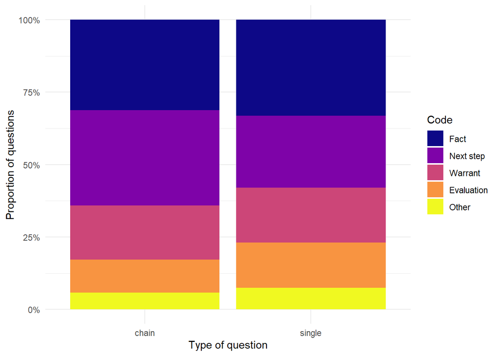

```r
qs_tally_by_cat_and_chain %>%
  group_by(code_name = collapsed_code) %>%
  summarise(across(contains("num_"), sum), .groups = "drop_last") %>%
  select(-num_qs) %>%
  pivot_longer(cols = starts_with("num_"), names_to = "type", values_to = "count", names_pattern = "num_(.*)_qs") %>%
  mutate(code_name = fct_relevel(code_name, "Fact", "Next step", "Warrant", "Evaluation", "Other")) %>%
  ggplot(aes(x = type)) +
  geom_bar(aes(y = count, fill = code_name),
           position = "fill",
           stat = "identity") +
  scale_fill_viridis_d("Code", option = "plasma") +
  scale_y_continuous(labels = scales::percent) +
  labs(x = "Type of question", y = "Proportion of questions")
```

## Wait time

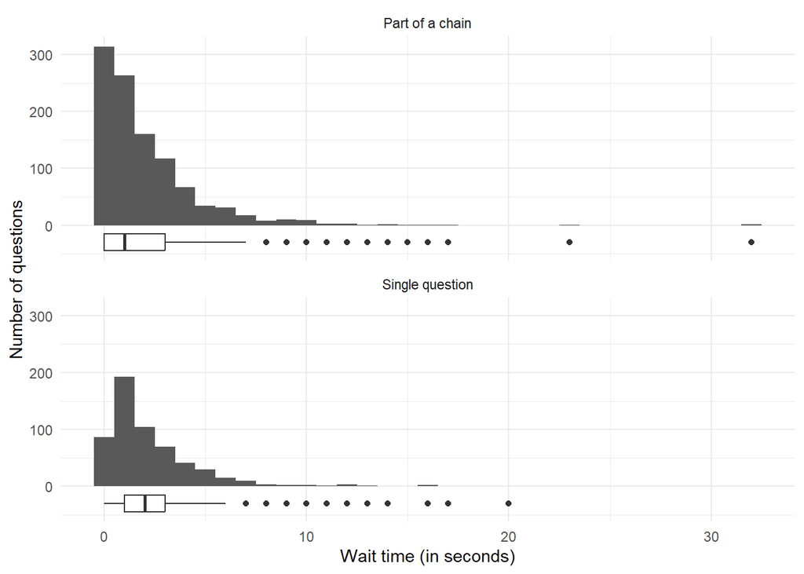

```r
numbered_chains %>%
  mutate(chain = if_else(is_cluster == "Y", "Part of a chain", "Single question")) %>%
  ggplot(aes(x = wait_time)) +
  geom_histogram(binwidth = 1) +
  geom_boxplot(width = 30, position = position_nudge(y = -30)) +
  facet_wrap(~ chain, ncol = 1) +
  labs(x = "Wait time (in seconds)", y = "Number of questions")
```

```r
find_mode <- function(x) {
  u <- unique(x)
  tab <- tabulate(match(x, u))
  u[tab == max(tab)]
}
numbered_chains %>%
  group_by(part_of_chain = is_cluster) %>%
  summarise(
    num_questions = n(),
    mean_wait_time = mean(wait_time),
    median_wait_time = median(wait_time),
    #mode_wait_time = purrr::map_dbl(wait_time, ~ which.max(tabulate(.x)))
    mode_wait_time = find_mode(wait_time)
  ) %>%
  rename_with(~ str_remove(., "_wait_time")) %>%
  basic_kable() %>%
  add_header_above(c(" " = 2, "Wait time (s)" = 3))
```

| part_of_chain | num_questions | Wait time (s) mean | Wait time (s) median | Wait time (s) mode |
| --- | --- | --- | --- | --- |
| N | 575 | 2.384348 | 2 | 1 |
| Y | 1045 | 2.072727 | 1 | 0 |

```r
numbered_chains %>%
  group_by(part_of_chain = is_cluster, is_last = pos_within_chain == num_in_chain) %>%
  summarise(
    num_questions = n(),
    mean_wait_time = mean(wait_time),
    median_wait_time = median(wait_time),
    #mode_wait_time = purrr::map_dbl(wait_time, ~ which.max(tabulate(.x)))
    mode_wait_time = find_mode(wait_time)
  ) %>%
  rename_with(~ str_remove(., "_wait_time")) %>%
  basic_kable() %>%
  add_header_above(c(" " = 3, "Wait time (s)" = 3))
```

| part_of_chain | is_last | num_questions | Wait time (s) mean | Wait time (s) median | Wait time (s) mode |
| --- | --- | --- | --- | --- | --- |
| N | TRUE | 575 | 2.384348 | 2 | 1 |
| Y | FALSE | 636 | 2.083333 | 1 | 0 |
| Y | TRUE | 409 | 2.056235 | 1 | 1 |